# Music_Mental_Health

Comparing the three model’s (Last random forest, bagging, XGBoost) accuracy using an ROC plot.

```r
library(pROC)
library(forecast)
roc1 = roc(test_data$Music.effects, rf_preds[,2])
roc2 = roc(test_data$Music.effects, bag_preds2[ , 2])
boost_preds <- predict(bst_1, dtest)
roc3 = roc(test_data$Music.effects, boost_preds)
```

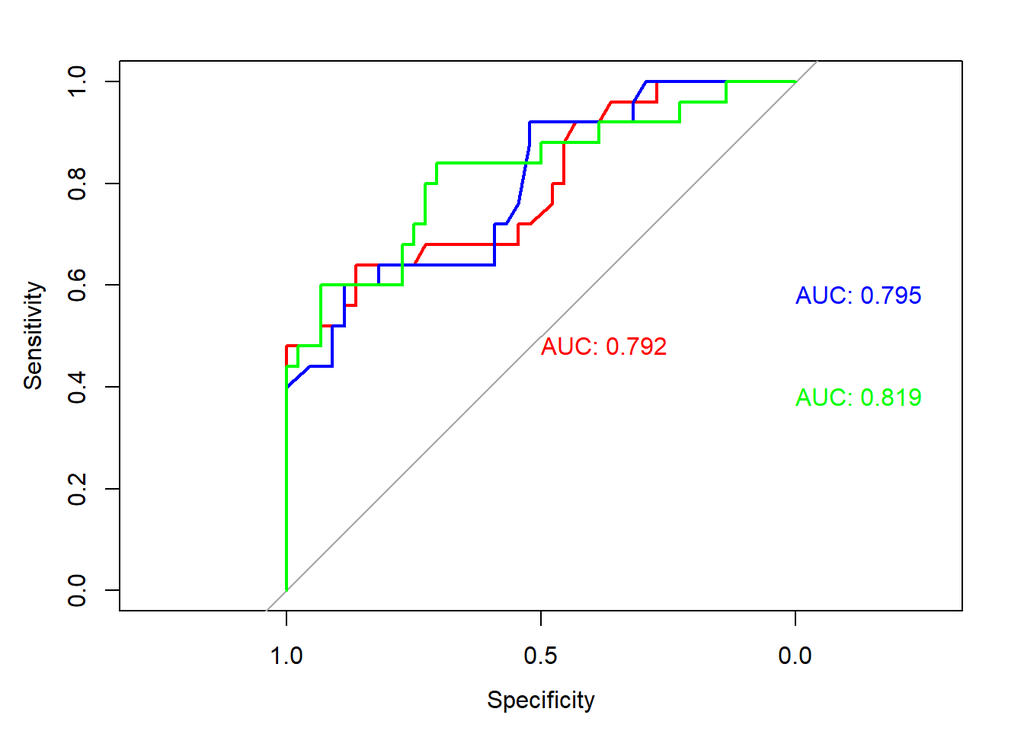

```r
plot.roc(roc1, print.auc = TRUE, col = "red", print.auc.col = "red")
# Print final model AUC
plot.roc(roc2, print.auc = TRUE, print.auc.x = 0, print.auc.y = 0.6, col ="blue", print.auc.col = "blue", add = TRUE)
plot.roc(roc3, print.auc = TRUE, print.auc.x = 0, print.auc.y = 0.4, col ="green", print.auc.col = "green", add = TRUE)
```

```r
library(dplyr)
```

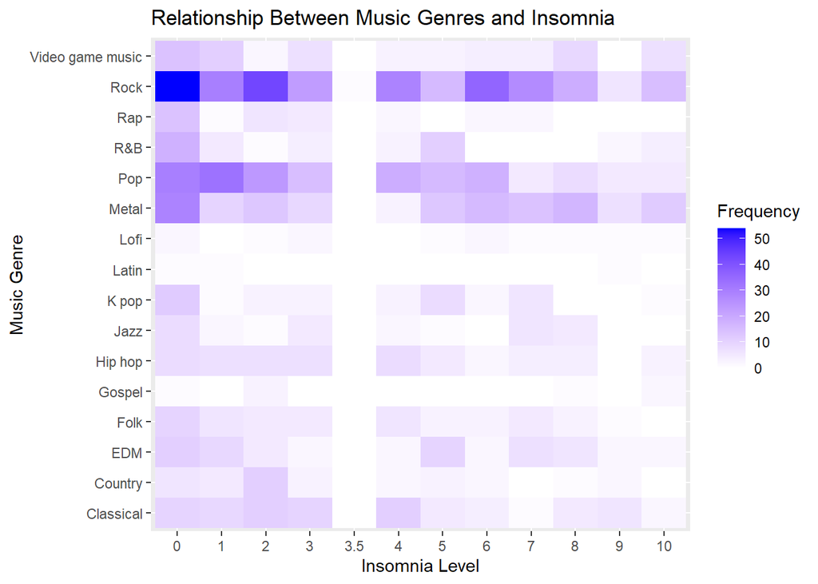

```r
library(ggplot2)
library(reshape2)
# Create a contingency table
contingency_table <- table(my_data$Fav.genre, my_data$Insomnia)

# Convert the table to a data frame
heatmap_data <- as.data.frame.matrix(contingency_table)

# Add row names as a new column
heatmap_data$Genre <- rownames(heatmap_data)

# Reshape the data to a long format
heatmap_long <- melt(heatmap_data, id.vars = "Genre", variable.name = "InsomniaLevel", value.name = "Frequency")

# Create the heatmap
ggplot(heatmap_long, aes(x = InsomniaLevel, y = Genre, fill = Frequency)) +
  geom_tile() +
  scale_fill_gradient(low = "white", high = "blue") +
  labs(title = "Relationship Between Music Genres and Insomnia",
       x = "Insomnia Level", y = "Music Genre")
```

From this heatmap, we can interpret the following:

Lighter shades represent a lower frequency of occurrences. For example, in the “Classical” row, lighter shades across the insomnia levels suggest that fewer respondents who listen to classical music reported those levels of insomnia.

The distribution across insomnia levels for each genre can give us an idea of the potential impact of that genre on sleep quality. If a music genre shows consistently darker colors at higher levels of insomnia, it might suggest a correlation where listeners of that genre report higher insomnia levels. Which in turn has a higher potential of affecting the listeners mental health.

Conversely, genres like “Pop” and “Metal” show a more spread out distribution of color intensity across the insomnia levels, indicating a more varied response in reported insomnia levels among their listeners.